# 04/01/2026 Update: Private Equity Figures

Author

Inder Majumdar

Published

April 1, 2026

# Motivation

The goal is to separate two related but distinct questions:

1. How has private equity activity in the Great Lakes region changed over time?
2. Which state-level PE exposure measures appear most relevant for Wisconsin?

## Figure 0: Indexed PE Activity Since 2019

Figure 0 indexes Great Lakes and national private equity activity to `2019 = 100`, allowing relative growth in deal count and deal value to be compared on the same scale.

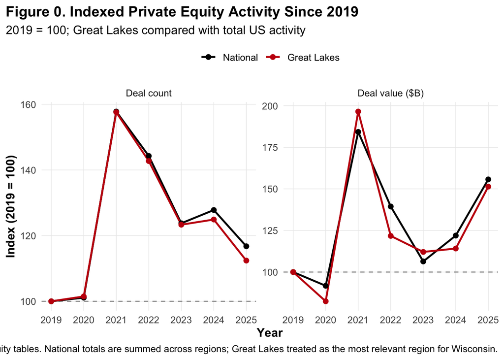

## Figure 1: Great Lakes PE Deal Flow Over Time

Figure 1 shows overall private equity deal count and deal value in the Great Lakes region from 2019 through 2025.

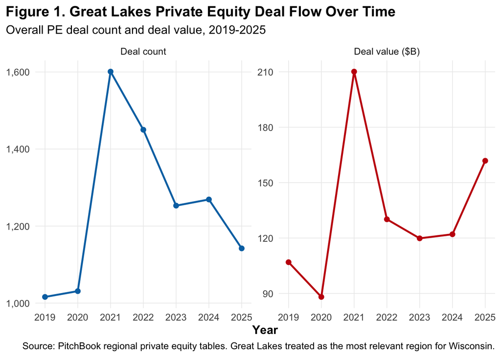

## Figure 2: Great Lakes Share of US Private Equity Activity

Figure 2 compares the Great Lakes share of US private equity activity in overall PE versus the middle market.

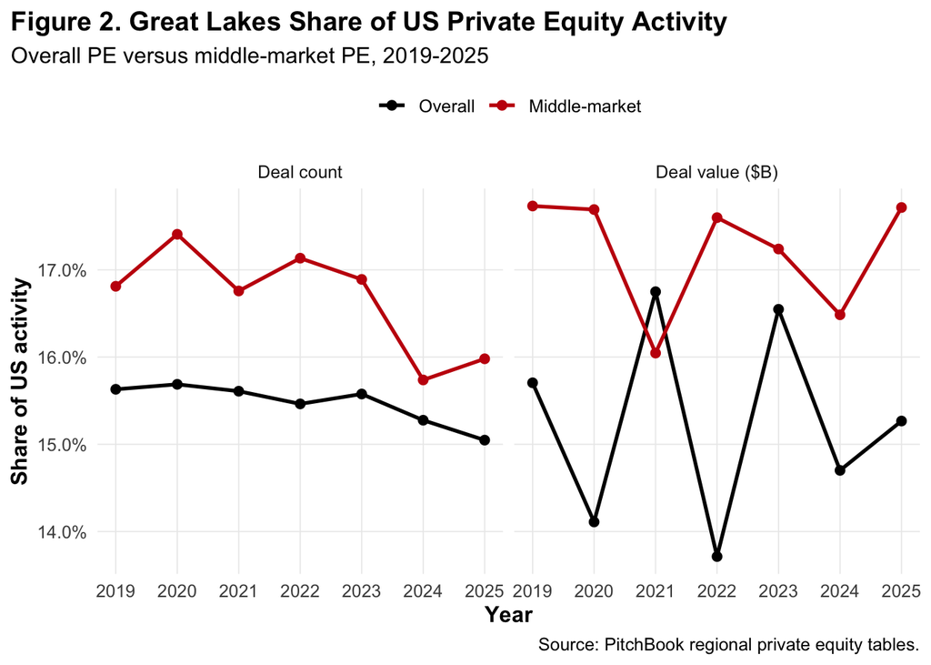

## State Exposure Measures

The remaining figures use the PE Risk Index data sheet. These are cross-sectional state exposure measures rather than state-level deal-flow counts.

## Figure 3: State Pension Assets Invested in Private Equity

Figure 3 maps the share of state pension assets invested in private equity. This is the strongest Wisconsin-specific PE signal in the raw state risk variables.

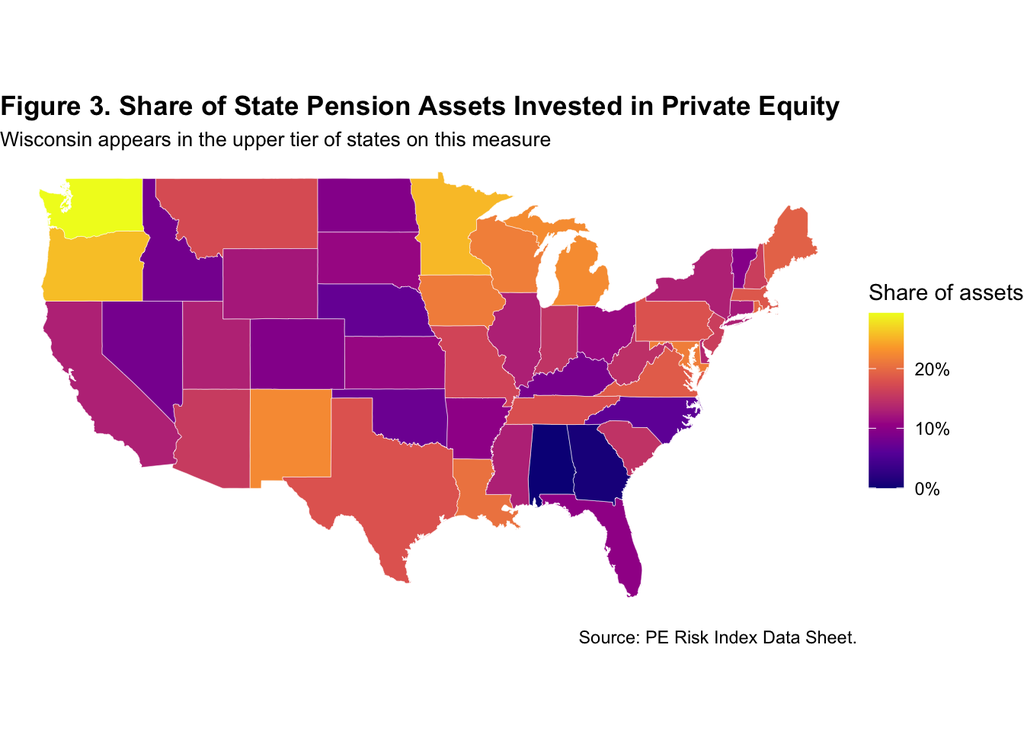

## Figure 4: Physician Specialty Concentration

Figure 4 ranks the top 10 states, plus Wisconsin, by the share of state population living in a metro where a single PE firm controls more than 30 percent of at least one physician specialty.

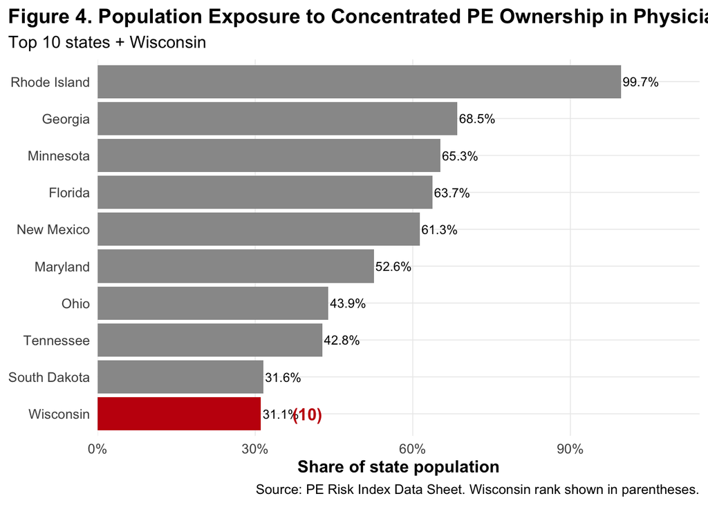

## Figure 5: Midwest Labor Exposure and Layoffs

Figure 5 compares Wisconsin with the same Midwest peer group used elsewhere in the report code base: Minnesota, Iowa, Illinois, Indiana, and Michigan. The dashed line in each panel shows the national median.

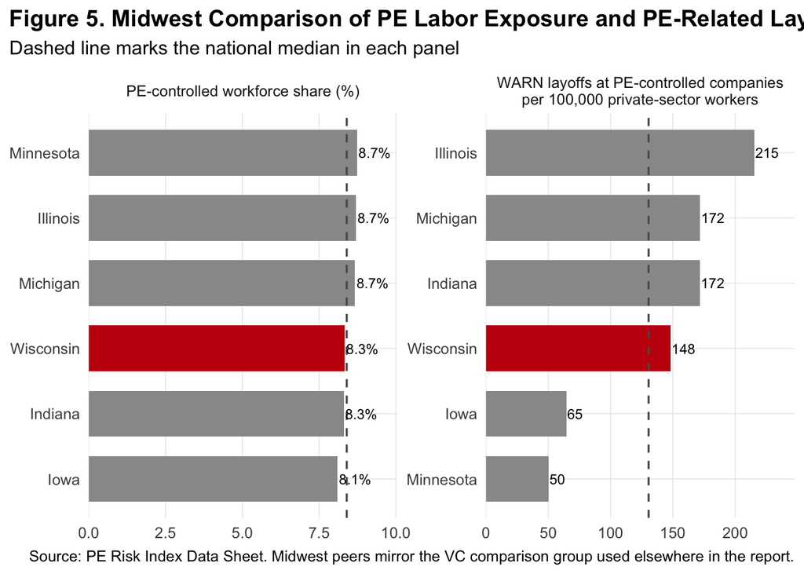